# Modelo para decesos basado en casos, Covid 19 - Chile

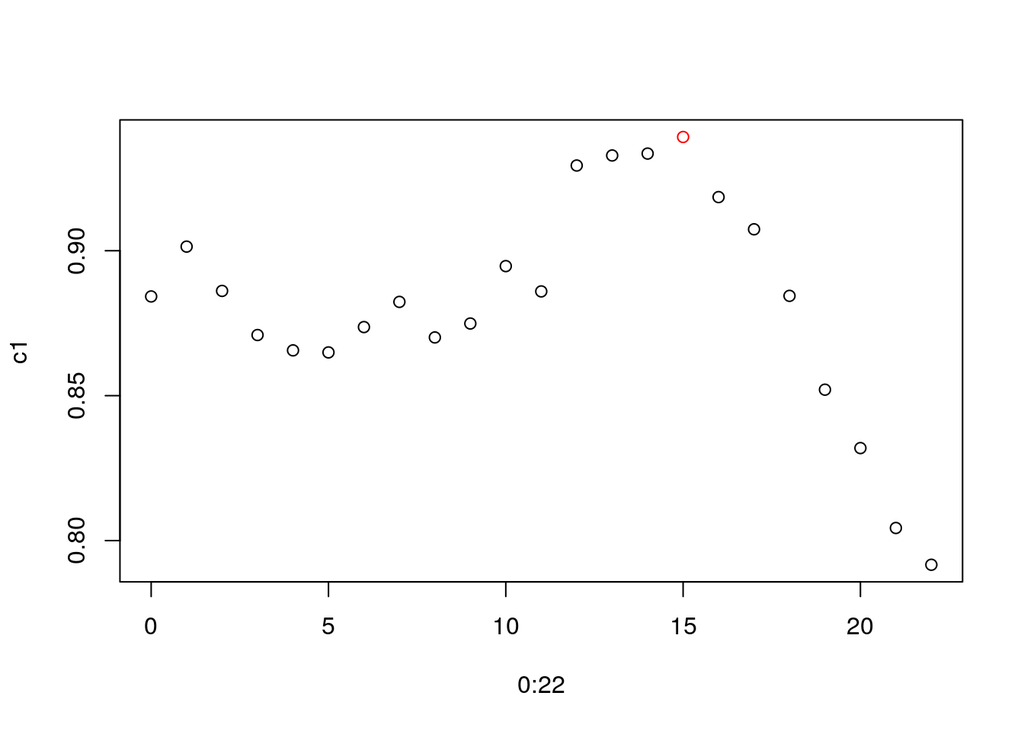

# Método 1: Modelo dinámico linear

Podemos hacer un modelo un poco bruto, en el cual modelamos el número de decesos actuales utilizando la cantidad de casos nuevos con lags de 0 a 14, más un autoregresivo sobre el mismo valor de decesos. Claramente, es un modelo sobreajustado.

```
##
## Time series regression with "ts" data:
## Start = 15, End = 78
##
## Call:
## dynlm(formula = chile.decesos.ts ~ L(chile.decesos.ts) + L(chile.casos.ts,
##     0:14), data = chile)
##
## Residuals:
##     Min      1Q  Median      3Q     Max
## -5.9646 -1.2333  0.1188  1.1833  4.7427
##
## Coefficients:
##                             Estimate Std. Error t value Pr(>|t|)
## (Intercept)                1.798e-01  4.978e-01   0.361 0.719538
## L(chile.decesos.ts)        4.441e-01  1.248e-01   3.559 0.000863 ***
## L(chile.casos.ts, 0:14)0  -1.796e-03  2.124e-03  -0.845 0.402141
## L(chile.casos.ts, 0:14)1   6.222e-03  2.502e-03   2.487 0.016502 *
## L(chile.casos.ts, 0:14)2  -3.891e-03  2.258e-03  -1.723 0.091409 .
## L(chile.casos.ts, 0:14)3  -5.953e-05  2.258e-03  -0.026 0.979077
## L(chile.casos.ts, 0:14)4  -4.402e-04  2.595e-03  -0.170 0.866038
## L(chile.casos.ts, 0:14)5   5.859e-04  3.014e-03   0.194 0.846739
## L(chile.casos.ts, 0:14)6   4.148e-04  2.759e-03   0.150 0.881118
## L(chile.casos.ts, 0:14)7  -1.642e-03  2.846e-03  -0.577 0.566616
## L(chile.casos.ts, 0:14)8  -1.252e-03  3.496e-03  -0.358 0.721829
## L(chile.casos.ts, 0:14)9  -1.490e-03  4.108e-03  -0.363 0.718438
## L(chile.casos.ts, 0:14)10  5.674e-03  4.465e-03   1.271 0.210108
## L(chile.casos.ts, 0:14)11 -7.297e-03  4.445e-03  -1.641 0.107377
## L(chile.casos.ts, 0:14)12  9.340e-03  4.974e-03   1.878 0.066632 .
## L(chile.casos.ts, 0:14)13 -1.744e-03  5.808e-03  -0.300 0.765242
## L(chile.casos.ts, 0:14)14  1.006e-02  5.027e-03   2.001 0.051225 .
## ---
## Signif. codes:  0 '***' 0.001 '**' 0.01 '*' 0.05 '.' 0.1 ' ' 1
##
## Residual standard error: 2.534 on 47 degrees of freedom
## Multiple R-squared:  0.926,  Adjusted R-squared:  0.9008
## F-statistic: 36.77 on 16 and 47 DF,  p-value: < 2.2e-16
```

Si analizamos supuestos, vemos que la relación no es lineal, con un claro patrón en U de los residuos, y que hay un leve aumento de varianza en los valores altos predichos. También podemos observar que existen residuos importantes, en valores con alto leverage.

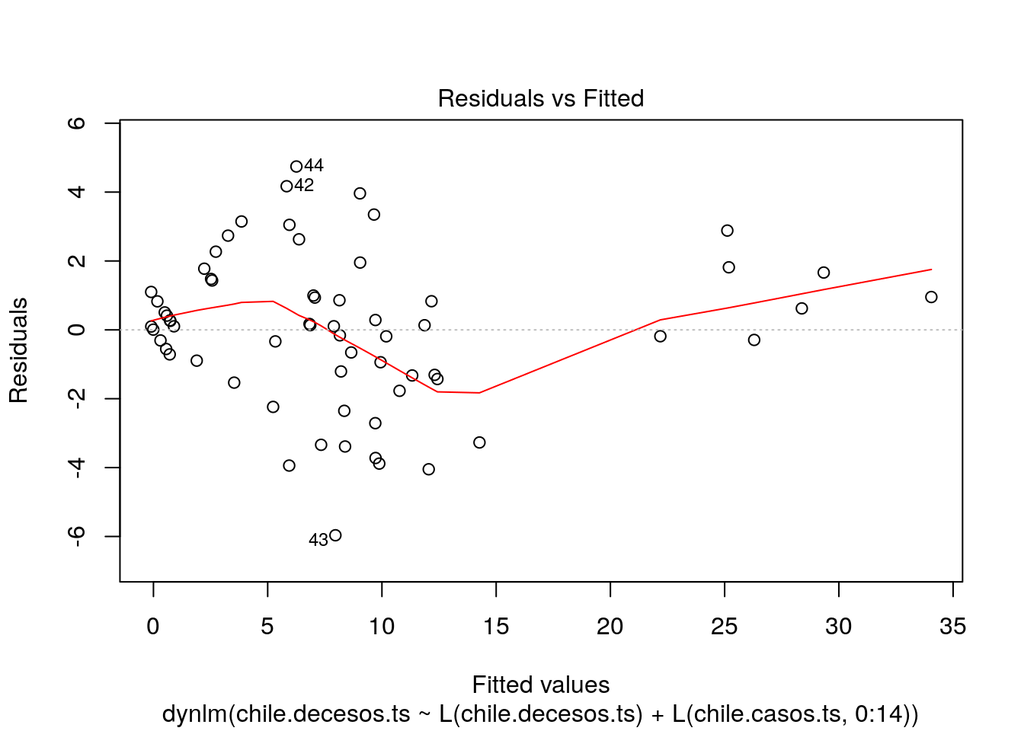

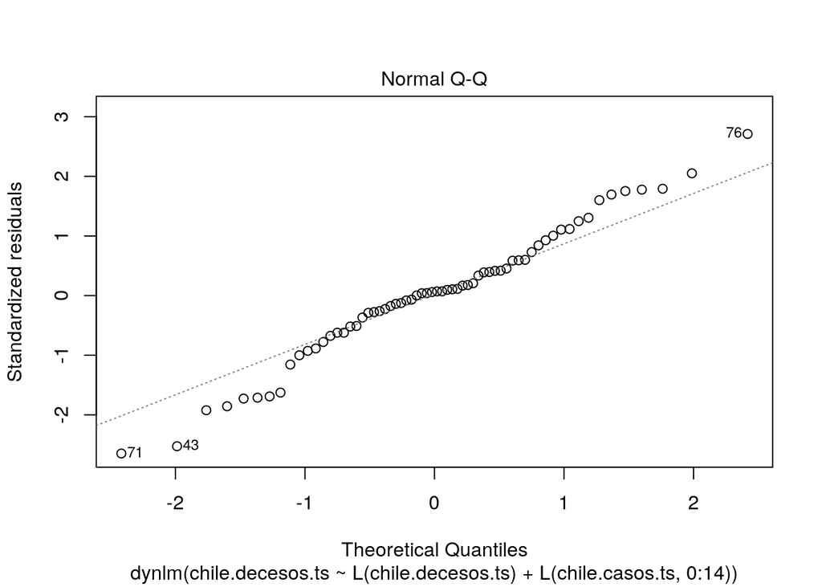

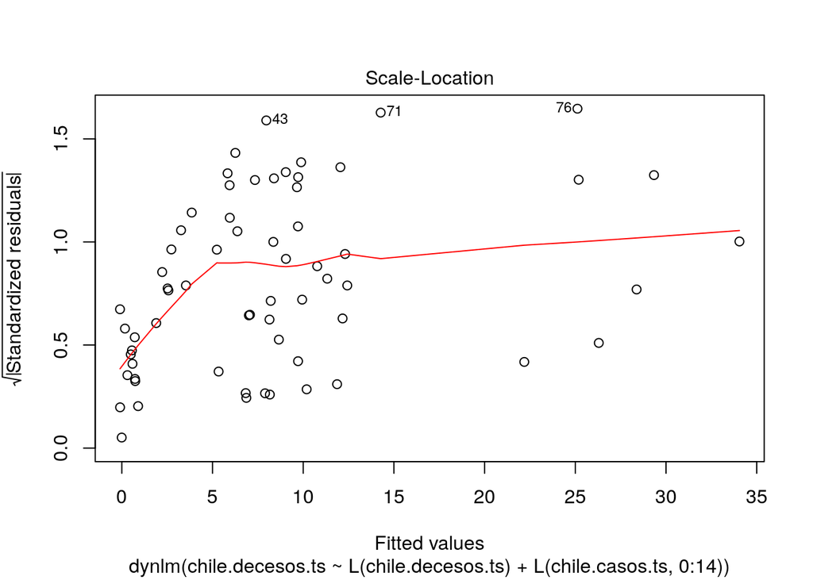

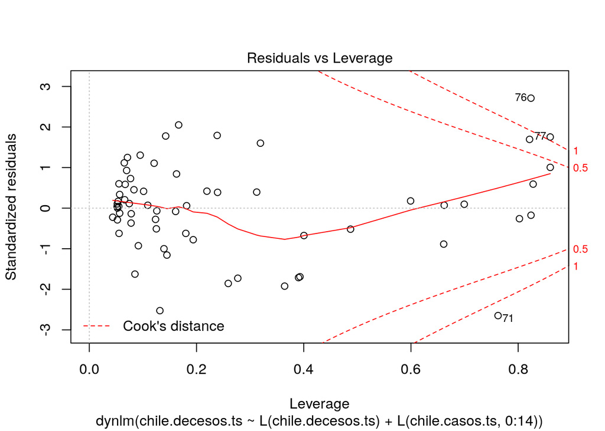

Si realizamos un análisis de validación con bootstrap, es muy claro el nivel de sobreajuste que tiene el modelo.

```
##           index.orig training    test optimism index.corrected  n
## R-square      0.9260   0.9477  0.7143   0.2334          0.6926 40
## MSE           4.7143   3.0294 18.2061 -15.1767         19.8910 40
## g             7.9366   7.5819  6.9902   0.5917          7.3449 40
## Intercept     0.0000   0.0000  1.0431  -1.0431          1.0431 40
## Slope         1.0000   1.0000  0.9008   0.0992          0.9008 40
```

## Regularización

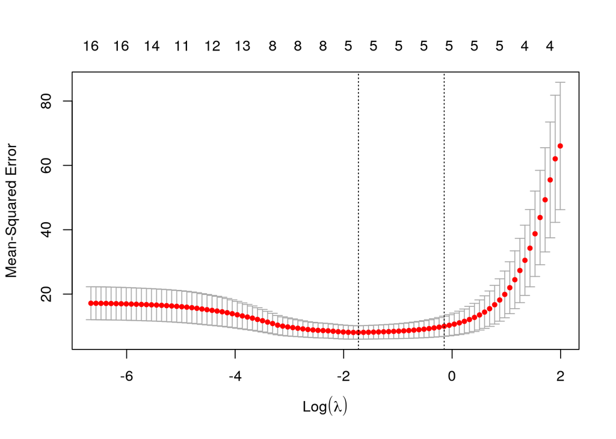

```
## 17 x 1 sparse Matrix of class "dgCMatrix"
##                                       1
## (Intercept)                1.0028065484
## L(chile.decesos.ts)        0.3814950297
## L(chile.casos.ts, 0:14).0  .
## L(chile.casos.ts, 0:14).1  0.0009927628
## L(chile.casos.ts, 0:14).2  .
## L(chile.casos.ts, 0:14).3  .
## L(chile.casos.ts, 0:14).4  .
## L(chile.casos.ts, 0:14).5  .
## L(chile.casos.ts, 0:14).6  .
## L(chile.casos.ts, 0:14).7  .
## L(chile.casos.ts, 0:14).8  .
## L(chile.casos.ts, 0:14).9  .
## L(chile.casos.ts, 0:14).10 .
## L(chile.casos.ts, 0:14).11 .
## L(chile.casos.ts, 0:14).12 0.0054493996
## L(chile.casos.ts, 0:14).13 0.0010285595
## L(chile.casos.ts, 0:14).14 0.0030239600
```

El R² es más bajo que el del modelo completo.

```
##        [,1]
## 1 0.9066617
```

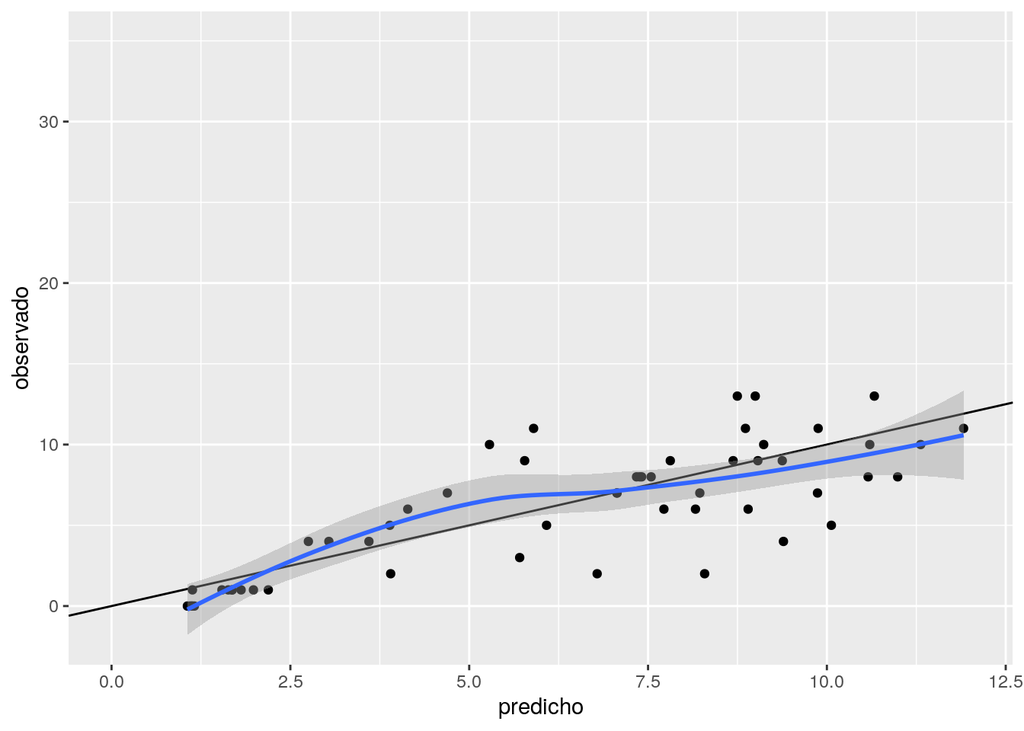

Probemos a validar el modelo previo.El R² es mejor que el del modelo con múltiples indicadores.

```
##           index.orig training    test optimism index.corrected  n
## R-square      0.9069   0.9094  0.8922   0.0171          0.8897 40
## MSE           5.9341   5.3180  6.8657  -1.5477          7.4818 40
## g             7.8993   7.7266  7.8537  -0.1271          8.0265 40
## Intercept     0.0000   0.0000 -0.0534   0.0534         -0.0534 40
## Slope         1.0000   1.0000  1.0169  -0.0169          1.0169 40
```

## Modelo Poisson

Primero, probemos un modelo Poisson con todos los coeficientes

```
##
## Call:
## glm(formula = yy ~ xx, family = "poisson", data = chile, x = T,
##     y = T)
##
## Deviance Residuals:
##      Min        1Q    Median        3Q       Max
## -2.42292  -1.00168  -0.06648   0.57650   2.45061
##
## Coefficients:
##                                Estimate Std. Error z value Pr(>|z|)
## (Intercept)                   1.065e+00  9.277e-02  11.479   <2e-16 ***
## xxL(chile.decesos.ts)         3.199e-02  1.786e-02   1.791   0.0733 .
## xxL(chile.casos.ts, 0:14).0  -4.580e-04  3.126e-04  -1.465   0.1429
## xxL(chile.casos.ts, 0:14).1   5.390e-04  3.605e-04   1.495   0.1349
## xxL(chile.casos.ts, 0:14).2  -5.994e-04  2.903e-04  -2.065   0.0389 *
## xxL(chile.casos.ts, 0:14).3  -3.534e-04  2.934e-04  -1.205   0.2284
## xxL(chile.casos.ts, 0:14).4  -8.839e-05  3.454e-04  -0.256   0.7980
## xxL(chile.casos.ts, 0:14).5   5.296e-05  4.078e-04   0.130   0.8967
## xxL(chile.casos.ts, 0:14).6  -8.353e-05  3.337e-04  -0.250   0.8023
## xxL(chile.casos.ts, 0:14).7  -2.155e-05  3.389e-04  -0.064   0.9493
## xxL(chile.casos.ts, 0:14).8   5.583e-04  4.591e-04   1.216   0.2239
## xxL(chile.casos.ts, 0:14).9   9.187e-06  5.643e-04   0.016   0.9870
## xxL(chile.casos.ts, 0:14).10  7.662e-04  6.166e-04   1.243   0.2140
## xxL(chile.casos.ts, 0:14).11 -3.296e-04  5.705e-04  -0.578   0.5634
## xxL(chile.casos.ts, 0:14).12  8.626e-04  6.593e-04   1.308   0.1907
## xxL(chile.casos.ts, 0:14).13 -4.329e-04  8.562e-04  -0.506   0.6131
## xxL(chile.casos.ts, 0:14).14  1.624e-03  7.361e-04   2.206   0.0274 *
## ---
## Signif. codes:  0 '***' 0.001 '**' 0.01 '*' 0.05 '.' 0.1 ' ' 1
##
## (Dispersion parameter for poisson family taken to be 1)
##
##     Null deviance: 433.526  on 63  degrees of freedom
## Residual deviance:  84.896  on 47  degrees of freedom
## AIC: 338.51
##
## Number of Fisher Scoring iterations: 5
```

La predicción es bastante buena!

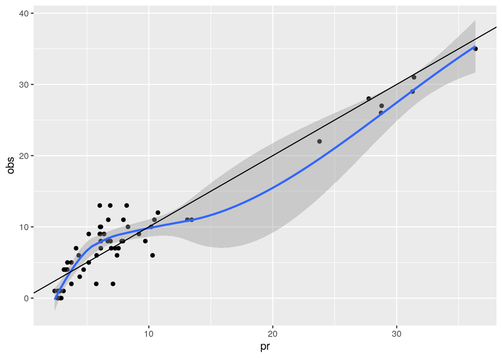

```
##
## Call:
## glm(formula = formula(paste0("decesos~", paste0("casos.", coef.rel -
##     1, collapse = " + "))), family = "poisson", data = chile,
##     x = T, y = T)
##
## Deviance Residuals:
##     Min       1Q   Median       3Q      Max
## -2.2811  -1.8606  -0.1754   1.0164   2.5672
##
## Coefficients:
##               Estimate Std. Error z value Pr(>|z|)
## (Intercept)  9.562e-01  7.529e-02  12.701  < 2e-16 ***
## casos.0     -1.966e-05  8.259e-05  -0.238  0.81181
## casos.2     -2.939e-04  1.673e-04  -1.757  0.07900 .
## casos.13     8.543e-04  2.761e-04   3.094  0.00197 **
## casos.14     1.294e-03  3.151e-04   4.107 4.01e-05 ***
## casos.15     6.141e-04  2.791e-04   2.200  0.02781 *
## ---
## Signif. codes:  0 '***' 0.001 '**' 0.01 '*' 0.05 '.' 0.1 ' ' 1
##
## (Dispersion parameter for poisson family taken to be 1)
##
##     Null deviance: 648.76  on 77  degrees of freedom
## Residual deviance: 182.66  on 72  degrees of freedom
## AIC: 414.27
##
## Number of Fisher Scoring iterations: 5
```

```
## [1] 0.844081
```

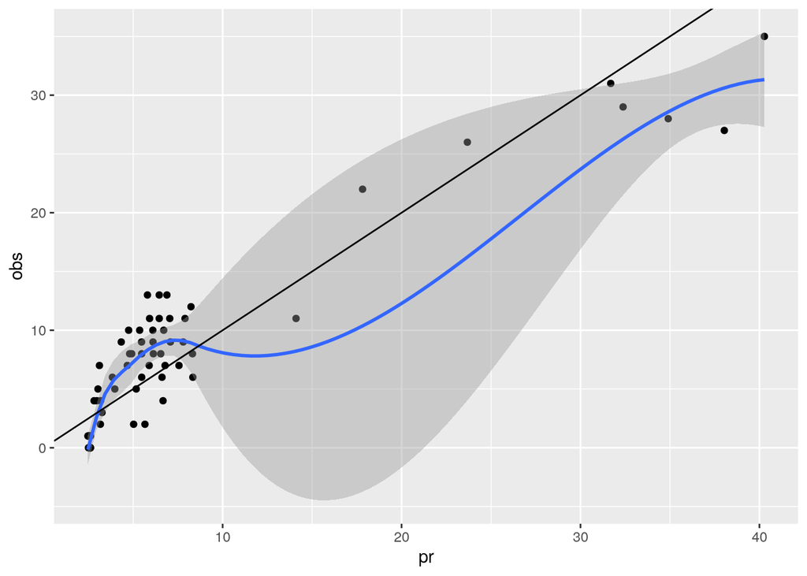